# Accidents data set

# Description

In the event of a car accident, there may be limited resources available for dealing with the ensuing property damage and injuries. In particular, there may be a limited number of people available with the ability to deliver high end medical attention if serious injuries have resulted from the accident. It would be useful if we could predict whether or not a serious injury resulted from the accident at the time the accident is reported. This could help us decide what kind of medical personnel should be sent out initially. To this end, 42,183 observations have been collected on automobile accidents. For each accident you have additional type of information, such as day of week, weather conditions, and road type.

- `HOUR_I_R`: 1 = rush hour, 0 = not (rush = 6-9 am, 4-7 pm)
- `ALCHL_I`: Alcohol involved = 1, not involved = 2
- `ALIGN_I`: 1 = straight, 2 = curve
- `STRATUM_R`: 1 = NASS Crashes Involving At Least One Passenger Vehicle (i.e., A Passenger Car, Sport Utility Vehicle, Pickup Truck Or Van) Towed Due To Damage From The Crash Scene And No Medium Or Heavy Trucks Are Involved. 0 = not
- `WRK_ZONE`: 1= yes, 0= no
- `WKDY_I_R`: 1=weekday, 0=weekend
- `INT_HWY`: Interstate? 1=yes, 0= no
- `LGTCON_I_R`: Light conditions - 1=day, 2=dark (including dawn/dusk), 3=dark, but lighted,4=dawn or dusk
- `MANCOL_I`: 0=no collision, 1=head-on, 2=other form of collision
- `PED_ACC_R`: 1=pedestrian/cyclist involved, 0=not
- `RELJCT_I_R`: 1=accident at intersection/interchange, 0=not at intersection
- `REL_RWY_R`: 1=accident on roadway, 0=not on roadway
- `PROFIL_I_R`: 1= level, 0=other
- `SPD_LIM`: Speed limit, miles per hour
- `SUR_CON`: Surface conditions (1=dry, 2=wet, 3=snow/slush, 4=ice, 5=sand/dirt/oil, 8=other, 9=unknown)
- `TRAF_CON_R`: Traffic control device: 0=none, 1=signal, 2=other (sign, officer, …)
- `TRAF_WAY`: 1=two-way traffic, 2=divided hwy, 3=one-way road
- `WEATHER_R`: 1=no adverse conditions, 2=rain, snow or other adverse condition
- `INJURY`: 1 = yes, 0 = no

# Load data and packages

```r
library(dplyr)
library(rpart)
library(rpart.plot)
library(xgboost)
```

Download the data:

```r
if (!file.exists("Accidents.csv"))
    download.file(
    'https://github.com/ChicagoBoothML/MLClassData/blob/master/TransportAccidents/Accidents.csv?raw=true',
    'Accidents.csv')
accidents_df = read.csv("Accidents.csv")

n = nrow(accidents_df)

accidents_df$INJURY = rep(1, n)
accidents_df$INJURY[accidents_df$MAX_SEV_IR == 0] = 0
drops = c("MAX_SEV_IR")
accidents_df = accidents_df[, !(names(accidents_df) %in% drops)]

accidents_df <- mutate_all(accidents_df, as.factor)
```

Next, we split data into train and test set. 80% of observations are kept in the training set.

```r
set.seed(1)
train_ind = sample.int(n, floor(0.8*n))
accidents_df_train = accidents_df[train_ind,]
accidents_df_test = accidents_df[-train_ind,]
```

# Predicting majority class

Without any information, we can think of accidents with injuries and without injuries as i.i.d. Bernoulli(p). Our best guess for p is fraction of accidents with injuries out of all injuries.

Table showing number of positive and negative examples:

```r
(tb_INJURY_train = table(accidents_df_train$INJURY))
```

```
##
##     0     1
## 16602 17144
```

Estimated probability of injury

```r
p_INJURY = tb_INJURY_train["1"] / (sum(tb_INJURY_train)); print(p_INJURY)
```

```
##        1
## 0.508031
```

It seems that the number of accidents with injury and without an injury is about the same. There are a bit more accidents with injury. Let us see what happens if we predict that every accident in the test set involves an injury.

```r
tb_INJURY_test = table(predictions = rep(1, nrow(accidents_df_test)),
                       actual = accidents_df_test$INJURY)
rownames(tb_INJURY_test) = c("predict_INJURY")
print(tb_INJURY_test)
```

```
##                 actual
## predictions         0    1
##   predict_INJURY 4119 4318
```

Accuracy of this approach would be

```r
tb_INJURY_test[1, "1"] / (sum(tb_INJURY_test))
```

```
## [1] 0.511793
```

We observe that both sets have balanced observations.

# Initial fit

We start by creating a big tree.

```r
big_tree = rpart(INJURY~., data=accidents_df_train,
                 control=rpart.control(minsplit=10,
                                       cp=0.0001,
                                       xval=10)
                 )
```

Next, we investigate `cptable` to find the a good value for the cp parameter

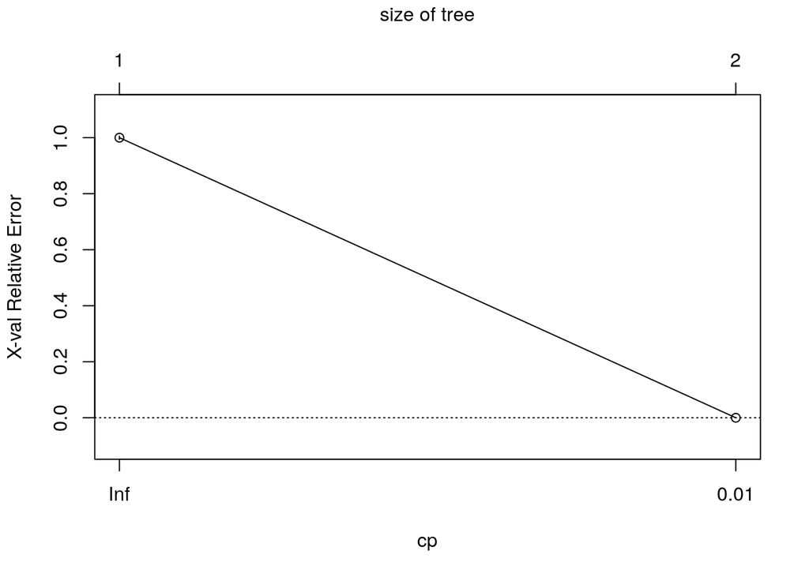

```r
plotcp(big_tree)
```

This is a strange looking error curve…. ????

Here is the cp table:

```r
cptable = printcp(big_tree)
```

```
##
## Classification tree:
## rpart(formula = INJURY ~ ., data = accidents_df_train, control = rpart.control(minsplit = 10,
##     cp = 1e-04, xval = 10))
##
## Variables actually used in tree construction:
## [1] NO_INJ_I
##
## Root node error: 16602/33746 = 0.492
##
## n= 33746
##
##      CP nsplit rel error xerror     xstd
## 1 1e+00      0         1      1 0.005532
## 2 1e-04      1         0      0 0.000000
```

Let us find the cp parameter with the smallest cv-errror.

```r
index_cp_min = which.min(cptable[,"xerror"])
(cp_min = cptable[ index_cp_min, "CP" ])
```

```
## [1] 1e-04
```

We use this cp value to prune the big tree.

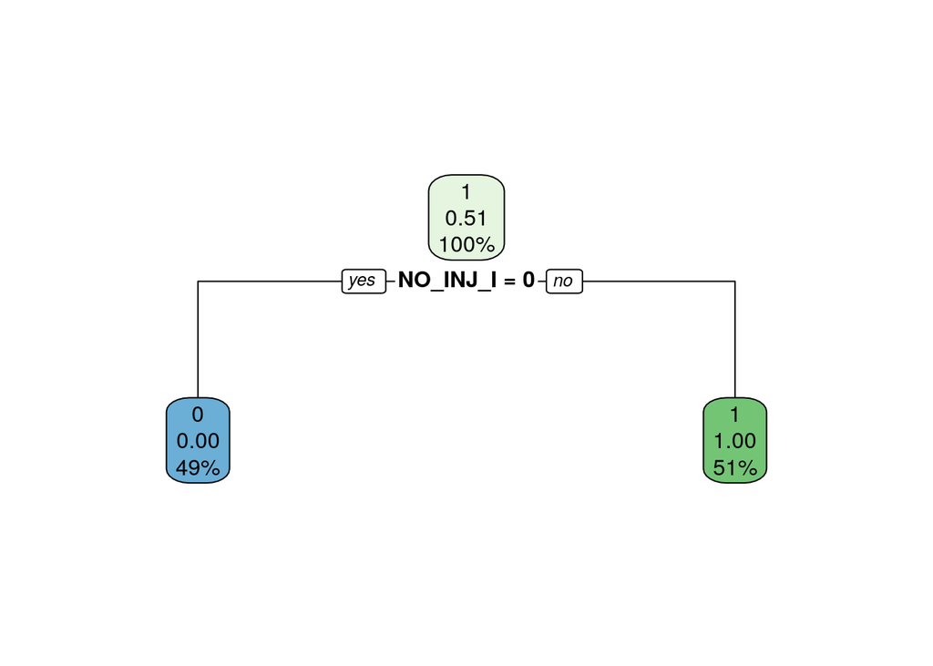

```r
optimal.tree = prune(big_tree, cp=cp_min)
rpart.plot(optimal.tree)
```

The following command will obtain predictions for the tree. It directly outputs the class label of the test examples.

```r
yhat = predict(optimal.tree, accidents_df_test, type="class")
```

The optimal tree has the following accuracy:

```r
mean(yhat == accidents_df_test$INJURY)
```

```
## [1] 0.999763
```

and the corresponding confusion matrix

```r
tb_tree = table(predictions = yhat,
                actual = accidents_df_test$INJURY)
rownames(tb_tree) = c("predict_NO_INJURY", "predict_INJURY")
print(tb_tree)
```

```
##                    actual
## predictions            0    1
##   predict_NO_INJURY 4119    2
##   predict_INJURY       0 4316
```

WE ARE ROCK STARS!!!!

… hold on …

`NO_INJ_I` is just opposite of `INJURY`…

… what a silly mistake.

We need to be careful not to include variables that are related to $Y$, but that are not useful for prediction.

Let us remove variables that essentially the same information as `INJURY`.

```r
drops = c("MAX_SEV_IR", "FATALITIES", "PRPTYDMG_CRASH", "NO_INJ_I", "INJURY_CRASH", "VEH_INVL")
accidents_df = accidents_df[, !(names(accidents_df) %in% drops)]
accidents_df_train = accidents_df_train[, !(names(accidents_df_train) %in% drops)]
accidents_df_test = accidents_df_test[, !(names(accidents_df_test) %in% drops)]
```

# Second fit

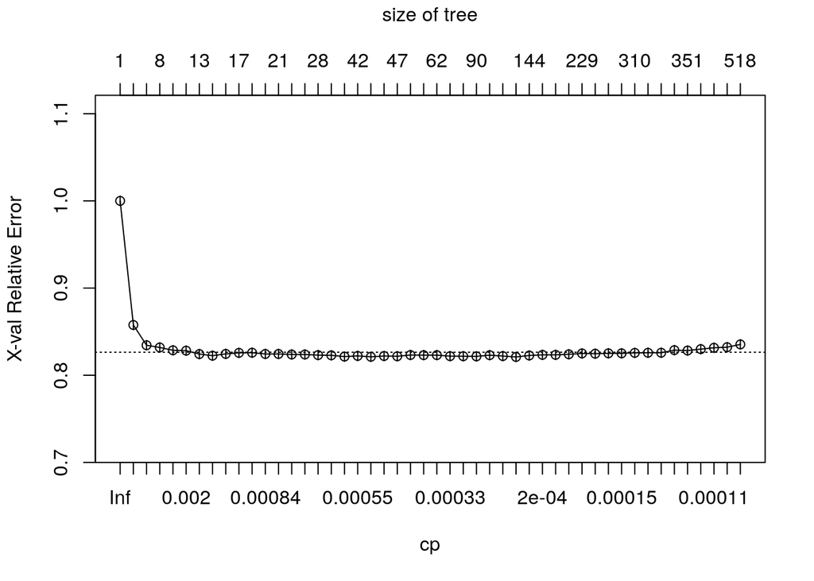

```r
big_tree = rpart(INJURY~., data=accidents_df_train,
                 control=rpart.control(minsplit=10,
                                       cp=0.0001,
                                       xval=10)
                 )
plotcp(big_tree)
```

We will find the largest cp that gives us estimate of the cross-validation error below the horizontal line on the plot. That is, we use the 1sd error rule.

```r
cptable = big_tree$cptable
index_cp_min = which.min(cptable[,"xerror"])
cp_min = cptable[ index_cp_min, "CP" ]
val_h = cptable[index_cp_min, "xerror"] + cptable[index_cp_min, "xstd"]
index_cp_std = Position(function(x) x < val_h, cptable[, "xerror"])
(cp_std = cptable[ index_cp_std, "CP" ])
```

```
## [1] 0.00156608
```

Subsequently, we prune the tree and make predictions.

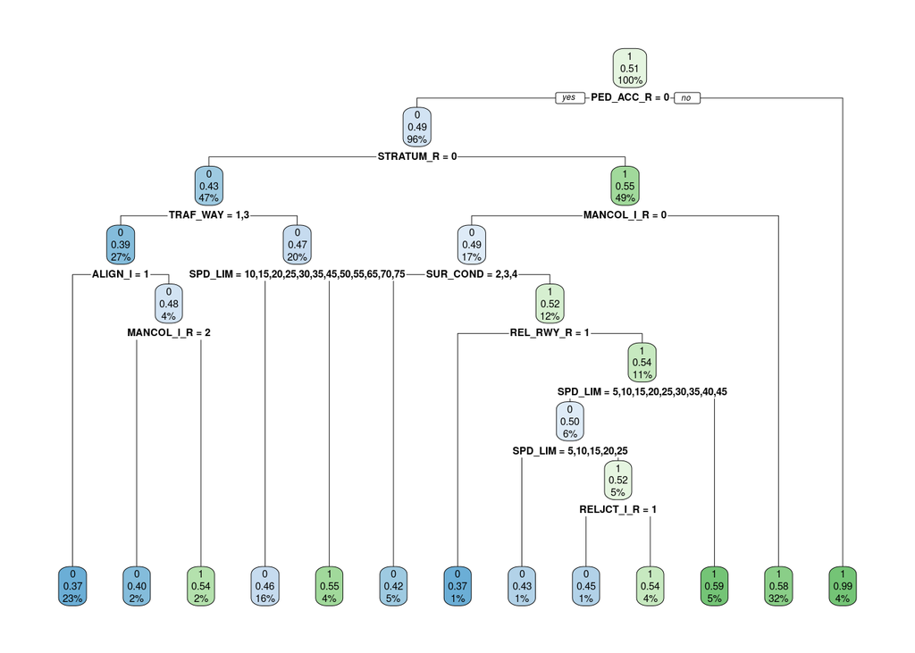

```r
optimal.tree = prune(big_tree, cp=cp_std)
rpart.plot(optimal.tree)
```

```r
yhat = predict(optimal.tree, accidents_df_test, type="class")
```

The optimal tree has the following accuracy:

```r
mean(yhat == accidents_df_test$INJURY)
```

```
## [1] 0.594524
```

and the corresponding confusion matrix

```r
tb_tree = table(predictions = yhat,
                actual = accidents_df_test$INJURY)
rownames(tb_tree) = c("predict_NO_INJURY", "predict_INJURY")
print(tb_tree)
```

```
##                    actual
## predictions            0    1
##   predict_NO_INJURY 2416 1718
##   predict_INJURY    1703 2600
```

# Let’s think again

If we care about making decisions whether to dispatch highly skillful medical staff, some information is not going to be available to us. For example, we may know if it is a rush hour or not, however, we may lack information about whether alcohol was involved or not. It is important to make sure that variables used to build a classifier are actually available at the time a classifier is used.

```r
drops = c("ALCHL_I", "STRATUM_R", "MANCOL_I", "PED_ACC_R", "SUR_CON", "TRAF_CON_R")
accidents_df = accidents_df[, !(names(accidents_df) %in% drops)]
accidents_df_train = accidents_df_train[, !(names(accidents_df_train) %in% drops)]
accidents_df_test = accidents_df_test[, !(names(accidents_df_test) %in% drops)]
```

# Decision Trees

We start by creating a big tree.

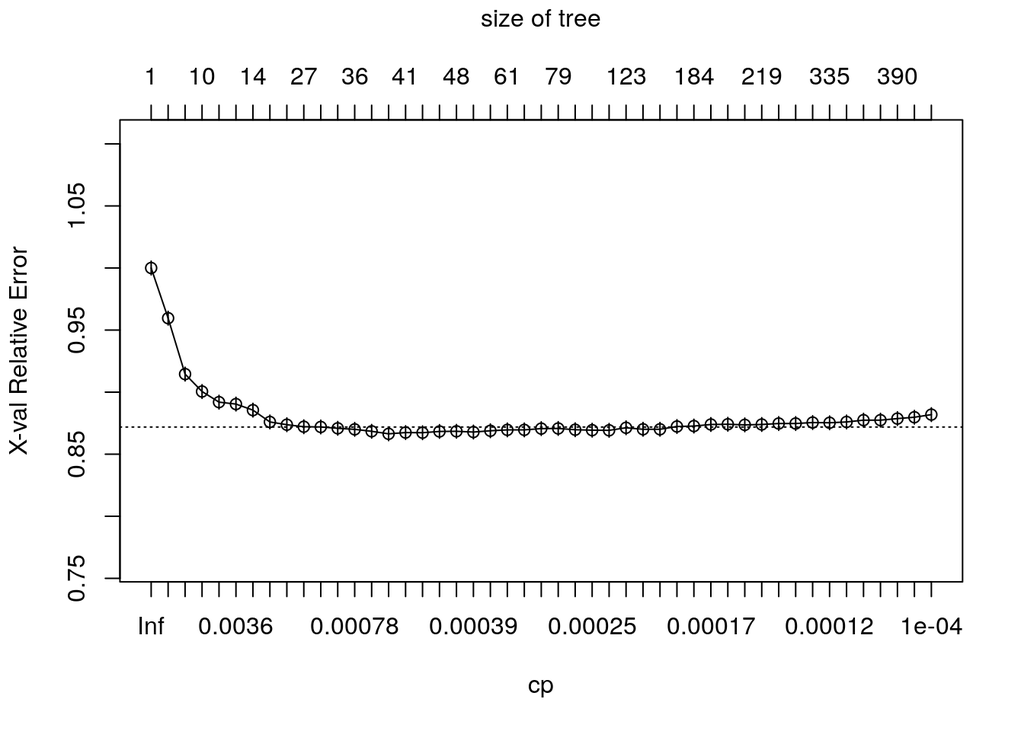

```r
big_tree = rpart(INJURY~., data=accidents_df_train,
                 control=rpart.control(minsplit=10,
                                       cp=0.0001,
                                       xval=10)
                 )
plotcp(big_tree)
```

```r
cptable = big_tree$cptable
index_cp_min = which.min(cptable[,"xerror"])
cp_min = cptable[ index_cp_min, "CP" ]
val_h = cptable[index_cp_min, "xerror"] + cptable[index_cp_min, "xstd"]
index_cp_std = Position(function(x) x < val_h, cptable[, "xerror"])
(cp_std = cptable[ index_cp_std, "CP" ])
```

```
## [1] 0.000843272
```

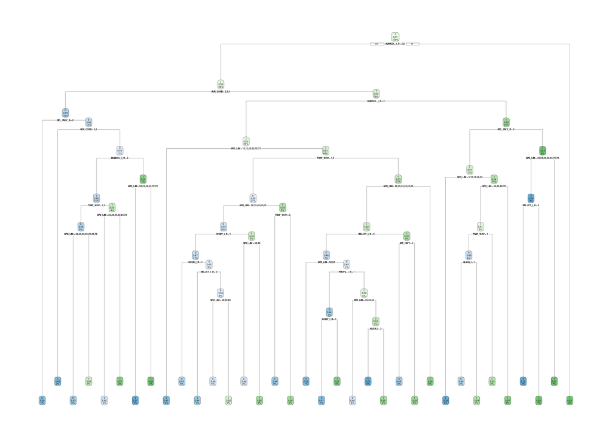

```r
optimal.tree = prune(big_tree, cp=cp_std)
rpart.plot(optimal.tree)
```

The optimal tree has the following accuracy:

```r
phat.tree = predict(optimal.tree, accidents_df_test)[,2]
yhat = predict(optimal.tree, accidents_df_test, type="class")
mean(yhat == accidents_df_test$INJURY)
```

```
## [1] 0.559796
```

and the corresponding confusion matrix

```r
tb_tree = table(predictions = yhat,
                actual = accidents_df_test$INJURY)
rownames(tb_tree) = c("predict_NO_INJURY", "predict_INJURY")
print(tb_tree)
```

```
##                    actual
## predictions            0    1
##   predict_NO_INJURY 2429 2024
##   predict_INJURY    1690 2294
```

# Boosting

Convert data to a matrix.

```r
 X = Matrix::sparse.model.matrix(INJURY ~ ., data=accidents_df)[,-1]
X.train = X[train_ind,]
X.test = X[-train_ind,]
Y.train = as.numeric(accidents_df_train$INJURY)-1
```

We fit boosting models for a few different settings.

```r
hyper_grid_xgb <- expand.grid(
  shrinkage = c(.01, .1),         ## controls the learning rate
  interaction.depth = c(1, 2, 4), ## tree depth
  bag.fraction = c(.5, .65, .8),  ##  percent of training data to sample for each tree
  optimal_trees = 0,              # a place to dump results
  min_RMSE = 0                    # a place to dump results
)
```

Fitting

```r
for(i in 1:nrow(hyper_grid_xgb)) {
  (i)
  # create parameter list
  params <- list(
    eta = hyper_grid_xgb$shrinkage[i],
    max_depth = hyper_grid_xgb$interaction.depth[i],
    subsample = hyper_grid_xgb$bag.fraction[i]
  )

  # reproducibility
  set.seed(41654)

  # train model
  xgb.tune <- xgb.cv(
    params               = params,
    data                 = X.train,
    label                = Y.train,
    nrounds              = 5000,
    nfold                = 5,
    objective            = "binary:logistic",
    verbose              = 0,
    verbosity            = 0,
    nthread              = 5,
    early_stopping_rounds = 10     # stop if no improvement for 10 consecutive trees
  )

  # add min training error and trees to grid
  hyper_grid_xgb$optimal_trees[i] <- which.min(xgb.tune$evaluation_log$test_logloss_mean)
  hyper_grid_xgb$min_RMSE[i] <- min(xgb.tune$evaluation_log$test_logloss_mean)
}
```

```r
(oo = hyper_grid_xgb %>%
      dplyr::arrange(min_RMSE) %>%
      head(10))
```

```
##    shrinkage interaction.depth bag.fraction optimal_trees min_RMSE
## 1       0.01                 4         0.80          1685 0.665385
## 2       0.01                 4         0.65          1460 0.665653
## 3       0.10                 4         0.80           156 0.665846
## 4       0.10                 4         0.65           154 0.665945
## 5       0.01                 4         0.50          1189 0.666203
## 6       0.10                 4         0.50           123 0.666604
## 7       0.10                 2         0.65           656 0.670474
## 8       0.10                 2         0.80           464 0.672224
## 9       0.10                 2         0.50           450 0.672570
## 10      0.01                 2         0.80          4257 0.672654
```

Refit the best model

```r
# parameter list
params <- list(
  eta = oo[1,]$shrinkage,
  max_depth = oo[1,]$interaction.depth,
  subsample = oo[1,]$bag.fraction
)

# train final model
xgb.fit.final <- xgboost(
  params = params,
  data = X.train,
  label = Y.train,
  nrounds = oo[1,]$optimal_trees,
  objective = "binary:logistic",
  verbose = 0,
  verbosity = 0
)
```

Predict on new data:

```r
phat.xgb = predict(xgb.fit.final, newdata=X.test)
yhat = rep(1, nrow(X.test))
yhat[phat.xgb < 0.5] = 0
mean(yhat == accidents_df_test$INJURY)
```

```
## [1] 0.565722
```

and the corresponding confusion matrix

```r
tb_tree = table(predictions = yhat,
                actual = accidents_df_test$INJURY)
rownames(tb_tree) = c("predict_NO_INJURY", "predict_INJURY")
print(tb_tree)
```

```
##                    actual
## predictions            0    1
##   predict_NO_INJURY 2415 1960
##   predict_INJURY    1704 2358
```

View variable importance plot

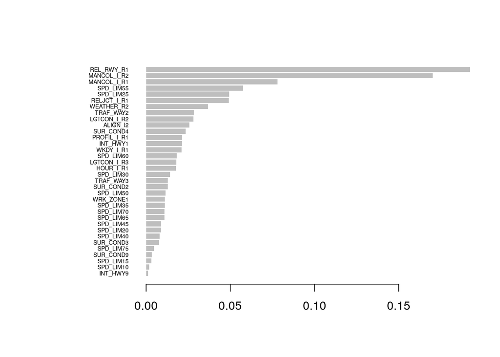

```r
mat <- xgb.importance(feature_names = colnames(X.train), model = xgb.fit.final)
xgb.plot.importance(importance_matrix = mat)
```

# ROC curves

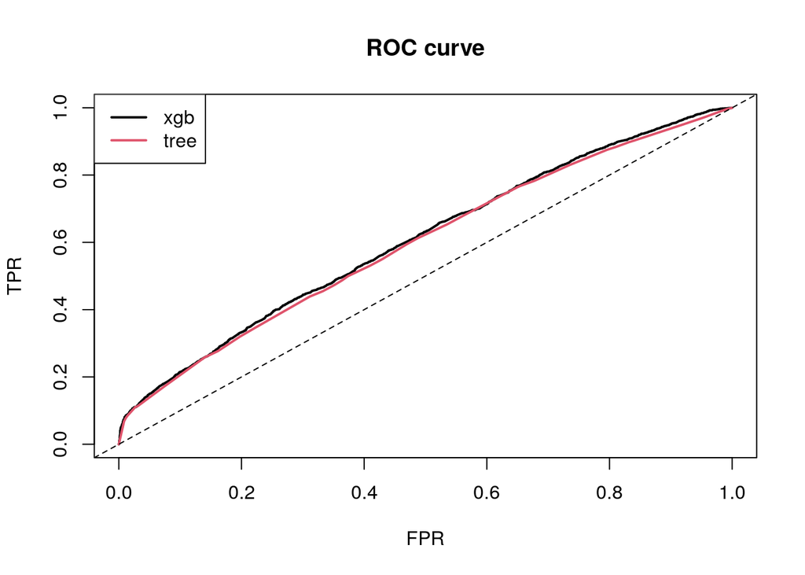

```r
library(ROCR)

pred = prediction(phat.xgb, accidents_df_test$INJURY)
perf = performance(pred, measure = "tpr", x.measure = "fpr")
plot(perf, col = 1, lwd = 2,
     main= 'ROC curve', xlab='FPR', ylab='TPR', cex.lab=1)

pred = prediction(phat.tree, accidents_df_test$INJURY)
perf = performance(pred, measure = "tpr", x.measure = "fpr")
plot(perf, add = T, col = i, lwd = 2)
abline(0,1,lty=2)
legend("topleft",legend=c('xgb', 'tree'), col=1:2, lwd=2)
```